# Data_Summary_for_SALT_Task_Force

Alene Onion

3/14/2022

## Median

Values are reduced to a median since 2001 for each site. The distribution within and outside the adirondack park is distinguished by color.

This first plot includes all waters as well as red lines to indicate the EPA aquatic(chronic) and aquatic(acute) criteria (230mg/L and 860 mg/L respectively).

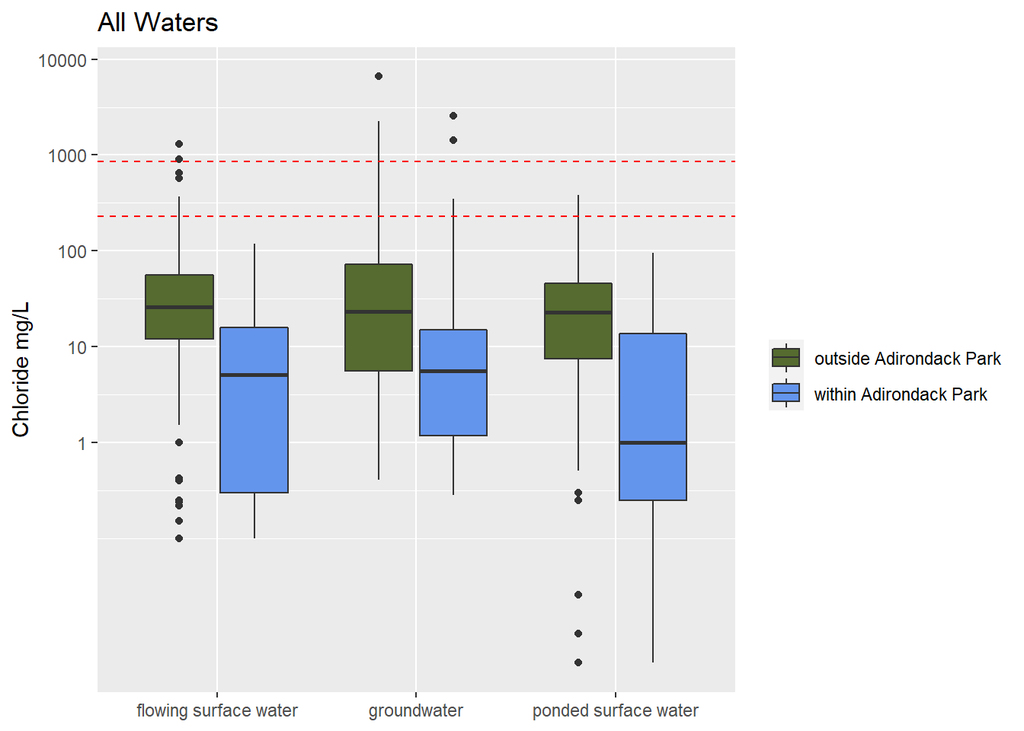

This second plot includes class A waters ONLY as well as red lines to indicate the NYSDEC water quality standard for the protection of water supply use (250 mg/L).

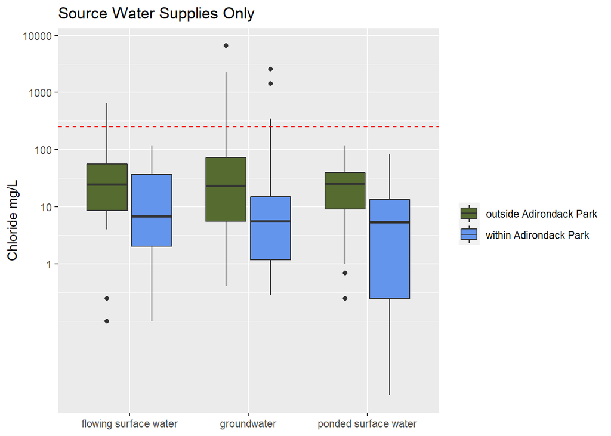

## Maximum

Values are reduced to the maximum value observed at each location since 2001.The distribution within and outside the adirondack park is distinguished by color.

This first plot includes all waters as well as red lines to indicate the EPA aquatic(chronic) and aquatic(acute) criteria (230mg/L and 860 mg/L respectively).

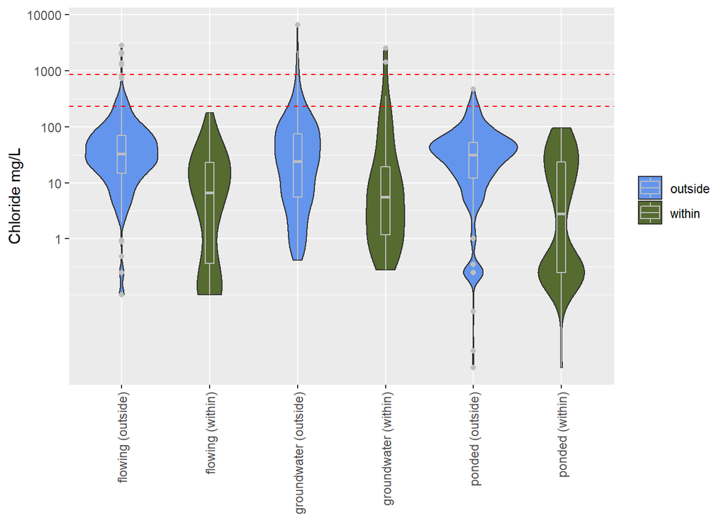

This second plot includes class A waters ONLY as well as red lines to indicate the NYSDEC water quality standard for the protection of water supply use (250 mg/L).

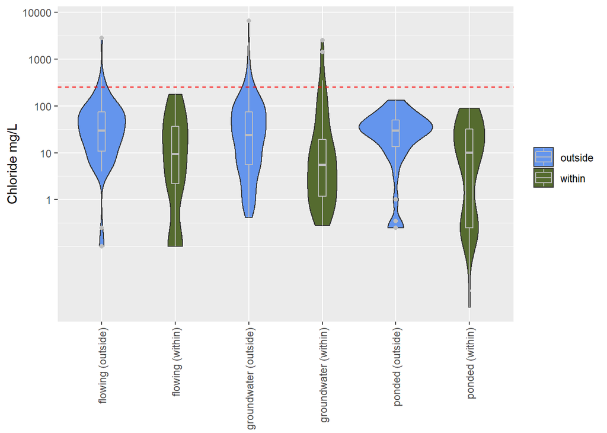